# JSON Vignette

Greg Janesch & Hongliang Liu

June 14, 2019

# 1 Introduction to JSON

JSON (JavaScript Object Notation) is a plain-text data file format. It was originally intended for use with JavaScript, as the full name implies, as it’s structured to store attribute-value pairs. As a result, it can be used to store data records containing nested and potentially complicated item fields. It is easy for humans to read and write. It is easy for machines to parse and generate. JSON is a text format that is completely language independent but uses conventions that are familiar to programmers of the C-family of languages, including C, C++, C#, Java, JavaScript, Perl, Python, and many others. These properties make JSON an ideal data-interchange language. [[Ref](https://www.json.org/)]

JSON is built on two parts:keys and values. Together they make a key/value pair.

Key: A key is always a string enclosed in quotation marks.  
Value: A value can be a string, number, boolean expression, array, or object.

A key value pair follows a specific syntax, with the key followed by a colon followed by the value. Key/value pairs are comma separated.[[Ref](https://developers.squarespace.com/what-is-json)]

In JSON, values must be one of the following data types:  
a string  
a number  
an object (JSON object)  
an array  
a boolean  
null

JSON values cannot be one of the following data types:  
a function  
a date  
undefined [[Ref](https://www.w3schools.com/js/js_json_datatypes.asp)]  
An example from the data we’ll be using later:

```
[
  {
    "Engine Information": {
      "Transmission": "6 Speed Automatic Select Shift",
      "Engine Type": "Audi 3.2L 6 cylinder 250hp 236ft-lbs",
      "Engine Statistics": {
        "Horsepower": 250,
        "Torque": 236
      },
      "Hybrid": false,
      "Number of Forward Gears": 6,
      "Driveline": "All-wheel drive"
    },
    "Identification": {
      "Make": "Audi",
      "Model Year": "2009 Audi A3",
      "ID": "2009 Audi A3 3.2",
      "Classification": "Automatic transmission",
      "Year": 2009
    },
    "Dimensions": {
      "Width": 202,
      "Length": 143,
      "Height": 140
    },
    "Fuel Information": {
      "Highway mpg": 25,
      "City mph": 18,
      "Fuel Type": "Gasoline"
    }
  },...
```

The individual record is denoted by the outermost pair of curly braces. Within that are the four data objects for this record (“Engine Information”, “Identification”, “Dimensions”, and “Fuel Information”), each of which comes with multiple subfields. Numeric, string, boolean, and array values can be stored in JSON objects. A fuller description of the syntax can be found [here](https://www.ecma-international.org/publications/standards/Ecma-404.htm).

# 2 JSON Packages in R

As one would expect with a popular file format, multiple methods exist for reading JSON into R. The `rjson` library is a very minimal package which doesn’t have any functionality beyond reading JSON data into R (it won’t even convert the contents to a data frame by itself). It was first implemented for R in 2007 by Alex Couture-Beil. It allows R users to convert JSON objects into R objects and vice-verse. There are three basic functions available in the `rjson` package: fromJSON, toJSON and newJSONParser.

Two other packages `RJSONIO` and `jsonlite` were introduced to R community since 2010 and 2013. They could be used as an alternative to the `rjson` package, but have some advantages than`rjson`. For example, RJSONIO package uses a C++ library - libjson, rather than implementing yet another JSON parser so that parsing would be faster than the rjson package. Compared with the two others, the `jsonlite` package is more powerful. It provides more options in the fromJSON/toJSON functions, which can convert data between JSON and R objects even through a http(s) connection, a pipe, even from a NoSQL database. In addtion, it can also interact with web APIs, building pipelines and streaming data between R and JSON. There is webpages provides a detailed comparison between three packages: [A biased comparsion of JSON packages in R](https://rstudio-pubs-static.s3.amazonaws.com/31702_9c22e3d1a0c44968a4a1f9656f1800ab.html). [[Ref](http://anotherpeak.org/blog/tech/2016/03/10/understand_json_3.html)]

For this vignette, we’ll use `jsonlite` for the above comparison. More usage about `jsonlite` could be found at the CRAN page and documentation [here](https://cran.r-project.org/web/packages/jsonlite/index.html)).

# 3 Working with JSON file in R

## 3.1 About the used JSON file

The dataset used is taken from the [CORGIS (Collection of Really Great, Interesting, Situated Datasets) project](https://think.cs.vt.edu/corgis/), a collection of moderately sized datasets intended for experimentation and learning how to handle data operations. It is about cars and how much fuel they use. Four types of information were included: “Engine Information”, “Identification”, “Dimensions”, “Fuel Information”.

The specific dataset can be found [here](https://think.cs.vt.edu/corgis/json/cars/cars.html).

## 3.2 Parse the JSON file to a R object

Reading in a file is fairly simple:

```r
library(tidyverse)
library(jsonlite)
json_data <- fromJSON("https://think.cs.vt.edu/corgis/json/cars/cars.json")
class(json_data)
```

```
## [1] "data.frame"
```

The function name is actually the same for all three packages mentioned before. However, the `rjson` and `RJSONIO` functions return a nested list, which would require some extra processing, so we stick with this for simplicity’s sake.

So this function apparently returns a data frame. However, if you try to look at the columns:

```r
# try to get the class of each column, but...
sapply(json_data, class)
```

```
## Engine Information     Identification         Dimensions
##       "data.frame"       "data.frame"       "data.frame"
##   Fuel Information
##       "data.frame"
```

The actual object is actually a collection of data frames (which was also called “nested data frame”“). We need to conver such a”nested data frame“” into a regular 2-dimensional regular dataframe. This is where the `flatten()` function in `jsonlite` comes in:

```r
# also convert to a tibble to make printing neater
actual_df <- tbl_df(jsonlite::flatten(json_data))
actual_df
```

```
## # A tibble: 5,076 x 18
##    `Engine Informa~ `Engine Informa~ `Engine Informa~ `Engine Informa~
##    <chr>            <chr>            <lgl>                       <int>
##  1 6 Speed Automat~ Audi 3.2L 6 cyl~ FALSE                           6
##  2 6 Speed Automat~ Audi 2.0L 4 cyl~ FALSE                           6
##  3 6 Speed Manual   Audi 2.0L 4 cyl~ FALSE                           6
##  4 6 Speed Automat~ Audi 2.0L 4 cyl~ FALSE                           6
##  5 6 Speed Automat~ Audi 2.0L 4 cyl~ FALSE                           6
##  6 6 Speed Manual   Audi 3.2L 6 cyl~ FALSE                           6
##  7 6 Speed Automat~ Audi 3.2L 6 cyl~ FALSE                           6
##  8 6 Speed Automat~ Audi 4.2L 8 cyl~ FALSE                           6
##  9 6 Speed Automat~ Audi 3.6L 6 cyl~ FALSE                           6
## 10 6 Speed Manual   Audi 2.0L 4 cyl~ FALSE                           6
## # ... with 5,066 more rows, and 14 more variables: `Engine
## #   Information.Driveline` <chr>, `Engine Information.Engine
## #   Statistics.Horsepower` <int>, `Engine Information.Engine
## #   Statistics.Torque` <int>, Identification.Make <chr>,
## #   `Identification.Model Year` <chr>, Identification.ID <chr>,
## #   Identification.Classification <chr>, Identification.Year <int>,
## #   Dimensions.Width <int>, Dimensions.Length <int>,
## #   Dimensions.Height <int>, `Fuel Information.Highway mpg` <int>, `Fuel
## #   Information.City mph` <int>, `Fuel Information.Fuel Type` <chr>
```

This returns a data frame that can be handled conventionally by R functions.

## 3.3 Exploratory analysis

It should be noted that there are some peculiarities in the data. For instance, documentation does not give units for the dimensions, and they don’t all seem to be on the same scale:

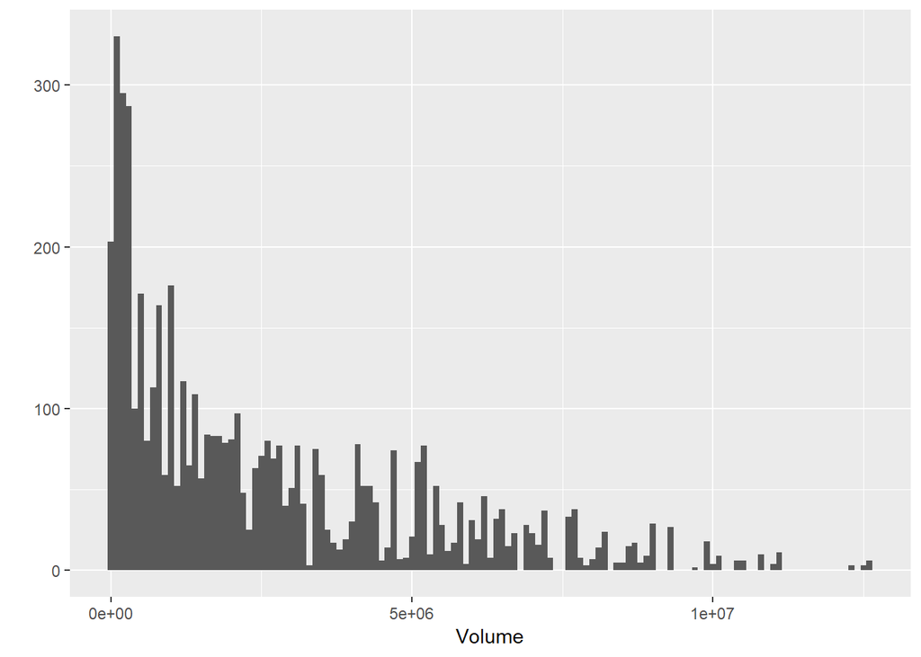

In fact, if we look at the min and max volumes calculated this way:

```
## [1]     1476 12556236
```

It’s different by a factor of nearly 10,000, which suggests an issue with that part of the data. Much of it looks reasonable, however, and this analysis will look more at variables that seem to be reasonably-valued.

First, a look at torque versus highway MPG:

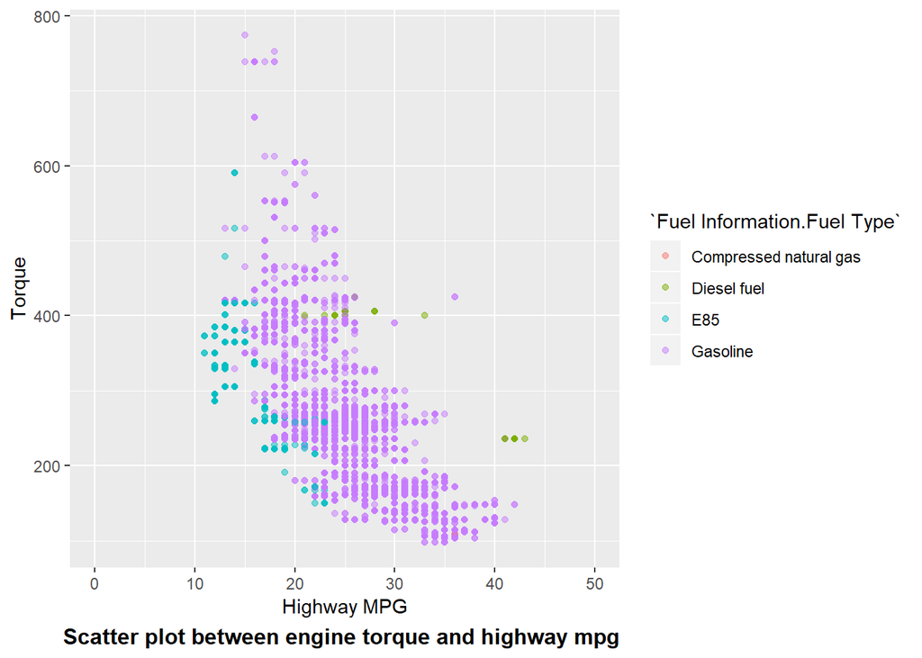

There are a couple of rough trends that can be pulled out. The biggest is probably the boost in higheay MPG as the torque levels fall - the highest amounts of torque correspond to under 20 MPG while the lowest torque levels are more around 35 MPG. The other is that the cars configured to run on E85 (an 85% ethanol fuel blend) have somewhat worse mileage than their gasoline counterparts. Breaking this down on just fuel type versus year:

|  | 2009 | 2010 | 2011 | 2012 |
| --- | --- | --- | --- | --- |
| Compressed natural gas | 0 | 1 | 1 | 0 |
| Diesel fuel | 1 | 8 | 9 | 9 |
| E85 | 0 | 147 | 219 | 90 |
| Gasoline | 48 | 1633 | 1794 | 1116 |

As you’d expect from the previous plot, the models were dominated by pure-gasoline engines, with a decently large number of E85 models as well. There are a few diesel and even a pair of compressed natural gas models (the two of these are the 2010 and 2011 Honda Civic).

Looking at the breakdown of hybrid vs non-hybrid mileage (this being the start of the 2010s, electric cars aren’t around), the highway mileage isn’t particularly different:

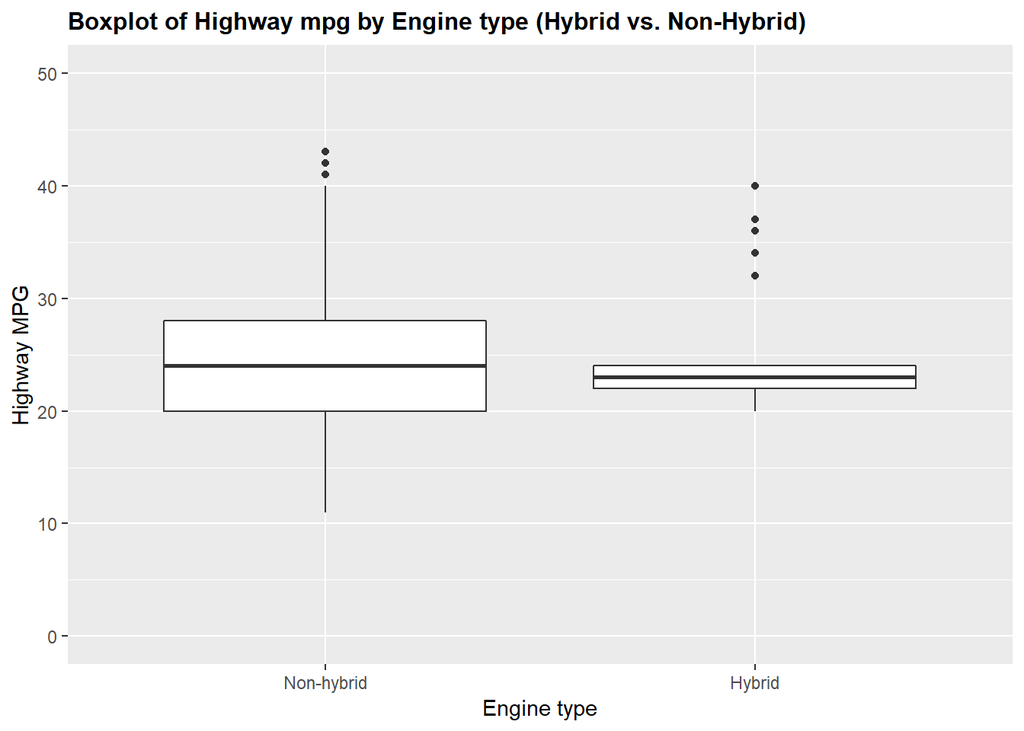

However, hybrid vehicles generally have better mileage at city speeds; looking at those mileages:

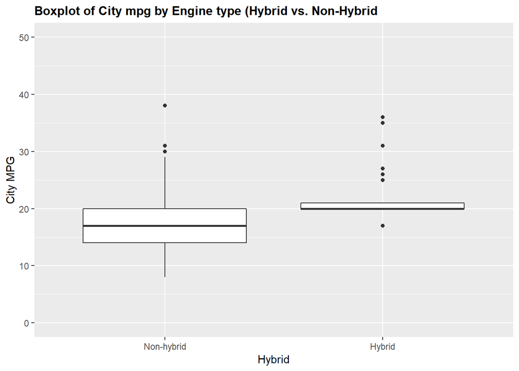

The median for the city mileage is quite a bit better than the one for the non-hybrid vehicle.

Finally, looking at manual vs automatic transmissions each year:

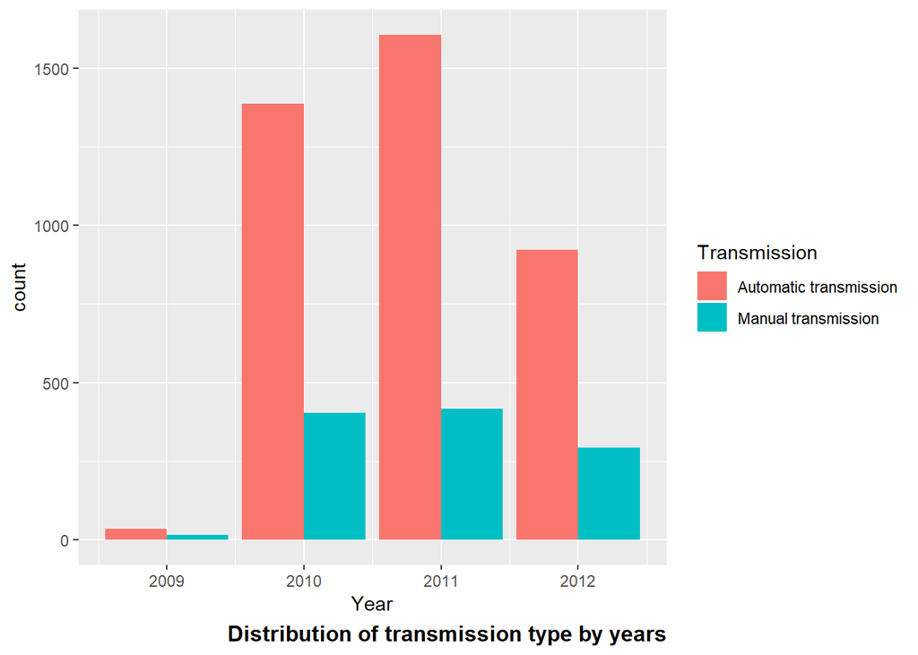

They seem similar proportionally, although it’s hard to tell in the 2009 case since that data looks incomplete.

Summry of horsepower by different transmissions

|  | Manual | Automatic |
| --- | --- | --- |
| Min | 100.0000 | 100.0000 |
| 25% | 158.0000 | 215.0000 |
| 50% | 200.0000 | 276.0000 |
| Mean | 238.9814 | 279.4943 |
| 75% | 300.0000 | 317.0000 |
| Max | 638.0000 | 631.0000 |
| Count | 1127.0000 | 3949.0000 |

It looks like the automatic transmissions tend to have somewhat more horsepower than the manual ones.